# Pertemuan 4 - Stationary Time Series Model

Fachry Wirayuda Alindri

2025-10-28

# White Noise

Membangkitkan white noise dengan peubah acak normal sebanyak 300.

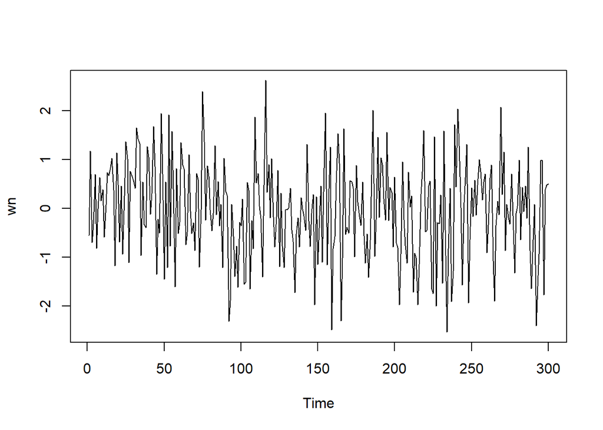

```r
set.seed(1062)
wn <- rnorm(300)
ts.plot(wn)
```

# Moving Average

## Proses MA(2)

### Manual

Membangkitkan proses MA(2) dengan $\theta_1$ = 0.4 dan $\theta_2$ = 0.6 sebanyak 300 dan c = 0.

MA(2) akan dibangkitkan dengan rumus

$$y_t = e_t + 0.4e_{t-1} + 0.6e_{t-2}$$

```r
set.seed(1062)
theta_1 <- 0.4
theta_2 <- 0.6

ma2 <- wn[c(1,2)]
for (i in 3:300){
  ma2[i] <- wn[i] + theta_1 * wn[i-1] + theta_2 * wn[i-2]
}
ma2
```

```
##   [1] -0.556759407  1.173156360 -0.567420342  0.099831997  0.142549584
##   [6] -0.739257662  0.077337001  0.134539330  0.400082192  0.825508193
##  [11] -0.345241818  0.062928662  0.404074861  1.003530963  1.538194429
##  [16]  1.758879938  1.283663007 -0.413690314  0.885264094  0.227250656
##  [21]  0.179397653  0.471624330 -1.171403193  0.150524260  0.901596142
##  [26]  1.707061612  0.113055285  0.923355767  0.294113193  1.289397306
##  [31]  1.032843489  2.158232404  2.331124051  2.888084509  0.416760008
##  [36]  0.950954496 -0.700904907 -0.204069609  0.906290094  1.322461210
##  [41]  1.060580383  0.883127254  1.723056075  1.706358481 -0.007771454
##  [46] -0.248910133 -1.405899388  1.602825567  1.172781239 -0.007255608
##  [51]  0.381834510 -1.864013855  1.756848266 -0.734343906  2.417072978
##  [56]  0.552773390 -0.504652232  0.405640068 -1.150381763 -0.002710011
##  [61]  0.922859187  1.256738831  1.964604190  0.103219006 -0.311291184
##  [66]  0.447260161  0.083832493  0.114479708 -0.537951263 -1.298179021
##  [71]  0.189567965  0.361043390 -0.541663467 -0.159173265  1.651055541
```

[output cut: 45 more lines]

### `arima.sim()`

Membangkitkan proses MA(2) dengan fungsi `arima.sim()`

```r
ma22 <- arima.sim(list(order=c(0,0,2), ma=c(theta_1,theta_2)), n=300)
ma22
```

```
## Time Series:
## Start = 1
## End = 300
## Frequency = 1
##   [1] -0.567420342  0.099831997  0.142549584 -0.739257662  0.077337001
##   [6]  0.134539330  0.400082192  0.825508193 -0.345241818  0.062928662
##  [11]  0.404074861  1.003530963  1.538194429  1.758879938  1.283663007
##  [16] -0.413690314  0.885264094  0.227250656  0.179397653  0.471624330
##  [21] -1.171403193  0.150524260  0.901596142  1.707061612  0.113055285
##  [26]  0.923355767  0.294113193  1.289397306  1.032843489  2.158232404
##  [31]  2.331124051  2.888084509  0.416760008  0.950954496 -0.700904907
##  [36] -0.204069609  0.906290094  1.322461210  1.060580383  0.883127254
##  [41]  1.723056075  1.706358481 -0.007771454 -0.248910133 -1.405899388
##  [46]  1.602825567  1.172781239 -0.007255608  0.381834510 -1.864013855
##  [51]  1.756848266 -0.734343906  2.417072978  0.552773390 -0.504652232
```

[output cut: 49 more lines]

## Karakteristik MA(2)

### Plot Time Series

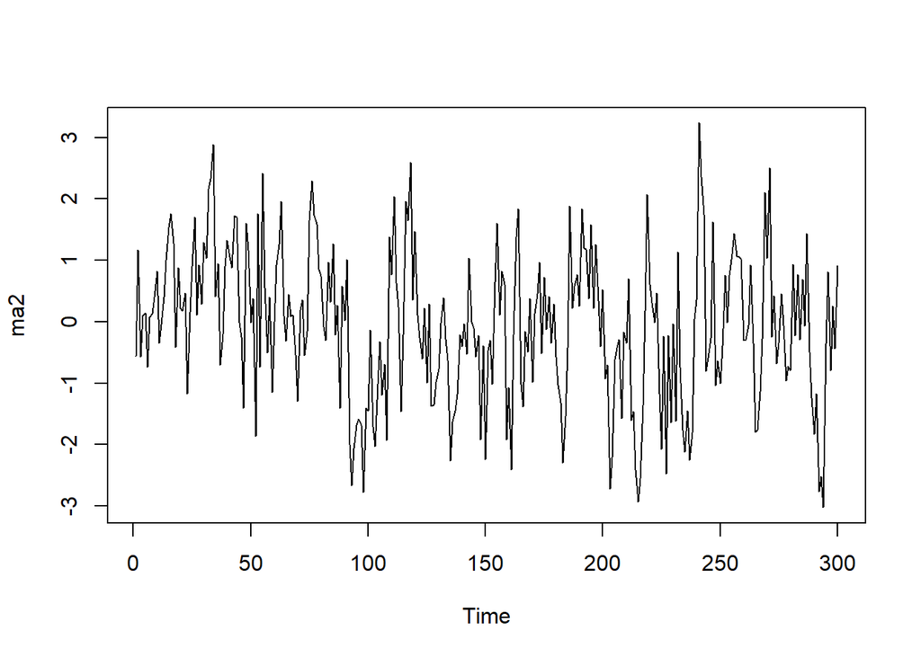

```r
ts.plot(ma2)
```

Berdasarkan plot time series, data MA(2) stasioner dalam rataan

### Plot ACF

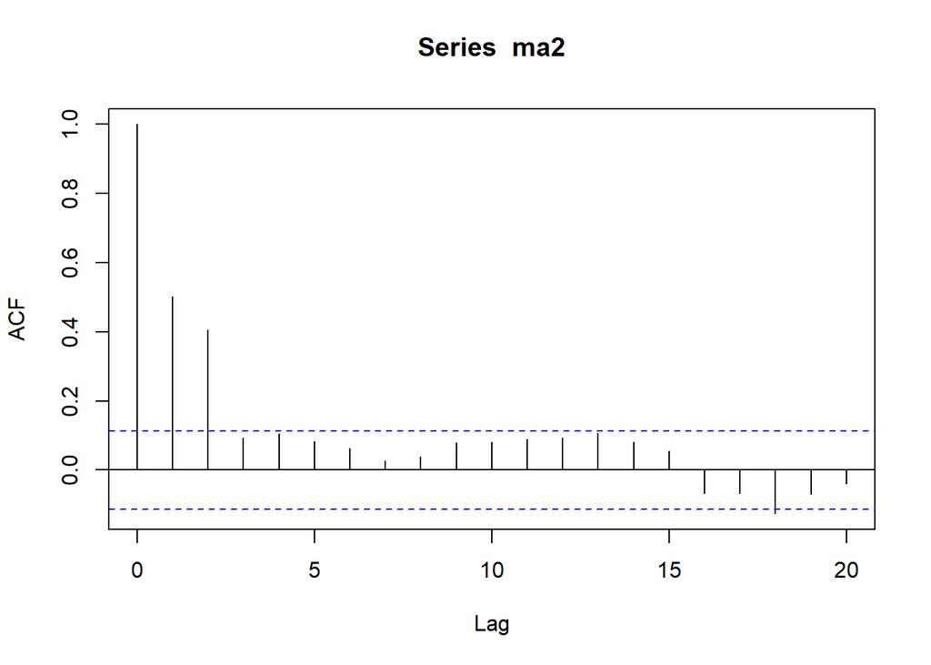

```r
acf(ma2,lag.max = 20)
```

Berdasarkan plot ACF, plot ACF *cuts off* di lag ke-dua

### Plot PACF

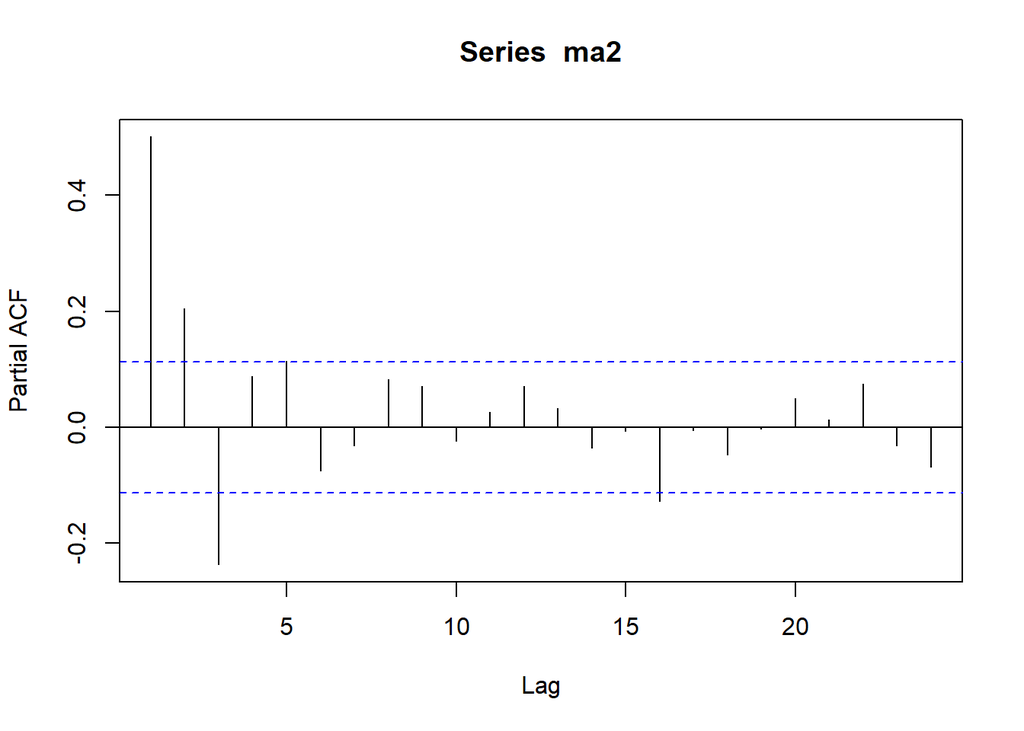

```r
pacf(ma2)
```

Berdasarkan plot PACF tersebut, terlihat bahwa plot PACF cenderung *tails off* dan membentuk gelombang sinus

### Plot EACF

```r
TSA::eacf(ma2)
```

```
## AR/MA
##   0 1 2 3 4 5 6 7 8 9 10 11 12 13
## 0 x x o o o o o o o o o  o  o  o
## 1 x x x o o o o o o o o  o  o  o
## 2 x x x o o o o o o o o  o  o  o
## 3 x x x o o o o o o o o  o  o  o
## 4 x x o x o o o o o o o  o  o  o
## 5 x x x o o o x o o o o  o  o  o
## 6 x x x o x o x o o o o  o  o  o
## 7 x x x x o x o o o o o  o  o  o
```

Berdasarkan plot EACF menunjukkan bahwa segitiga nol berada pada ordo AR(0) dan MA(2)

### Scatter Plot antar Lag

#### Korelasi antara $Y_t$ dengan $Y_{t-1}$

```r
#Yt
yt_ma <- ma2[-1]
yt_ma
```

```
##   [1]  1.173156360 -0.567420342  0.099831997  0.142549584 -0.739257662
##   [6]  0.077337001  0.134539330  0.400082192  0.825508193 -0.345241818
##  [11]  0.062928662  0.404074861  1.003530963  1.538194429  1.758879938
##  [16]  1.283663007 -0.413690314  0.885264094  0.227250656  0.179397653
##  [21]  0.471624330 -1.171403193  0.150524260  0.901596142  1.707061612
##  [26]  0.113055285  0.923355767  0.294113193  1.289397306  1.032843489
##  [31]  2.158232404  2.331124051  2.888084509  0.416760008  0.950954496
##  [36] -0.700904907 -0.204069609  0.906290094  1.322461210  1.060580383
##  [41]  0.883127254  1.723056075  1.706358481 -0.007771454 -0.248910133
##  [46] -1.405899388  1.602825567  1.172781239 -0.007255608  0.381834510
##  [51] -1.864013855  1.756848266 -0.734343906  2.417072978  0.552773390
##  [56] -0.504652232  0.405640068 -1.150381763 -0.002710011  0.922859187
##  [61]  1.256738831  1.964604190  0.103219006 -0.311291184  0.447260161
##  [66]  0.083832493  0.114479708 -0.537951263 -1.298179021  0.189567965
##  [71]  0.361043390 -0.541663467 -0.159173265  1.651055541  2.296689228
```

[output cut: 45 more lines]

```r
#Yt-1
yt_1_ma <- ma2[-300]
yt_1_ma
```

```
##   [1] -0.556759407  1.173156360 -0.567420342  0.099831997  0.142549584
##   [6] -0.739257662  0.077337001  0.134539330  0.400082192  0.825508193
##  [11] -0.345241818  0.062928662  0.404074861  1.003530963  1.538194429
##  [16]  1.758879938  1.283663007 -0.413690314  0.885264094  0.227250656
##  [21]  0.179397653  0.471624330 -1.171403193  0.150524260  0.901596142
##  [26]  1.707061612  0.113055285  0.923355767  0.294113193  1.289397306
##  [31]  1.032843489  2.158232404  2.331124051  2.888084509  0.416760008
##  [36]  0.950954496 -0.700904907 -0.204069609  0.906290094  1.322461210
##  [41]  1.060580383  0.883127254  1.723056075  1.706358481 -0.007771454
##  [46] -0.248910133 -1.405899388  1.602825567  1.172781239 -0.007255608
##  [51]  0.381834510 -1.864013855  1.756848266 -0.734343906  2.417072978
##  [56]  0.552773390 -0.504652232  0.405640068 -1.150381763 -0.002710011
##  [61]  0.922859187  1.256738831  1.964604190  0.103219006 -0.311291184
##  [66]  0.447260161  0.083832493  0.114479708 -0.537951263 -1.298179021
##  [71]  0.189567965  0.361043390 -0.541663467 -0.159173265  1.651055541
```

[output cut: 45 more lines]

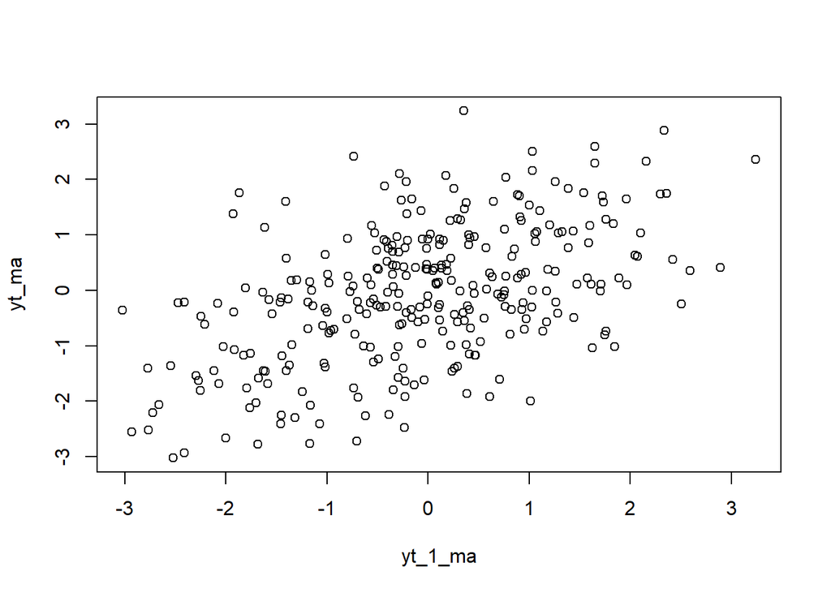

```r
plot(y = yt_ma, x= yt_1_ma)
```

Berdasarkan scatter plot terlihat ada hubungan antara $Y_t$ dengan $Y_{t-1}$

```r
cor(yt_ma,yt_1_ma)
```

```
## [1] 0.5018446
```

Secara teoritis bisa dihitung dengan rumus:

$$\dfrac{\theta_1 + \theta_1\theta_2}{1+\theta_1^2+\theta_2^2}$$

```r
#teoritis

rho_1 <- (theta_1 + theta_1*theta_2) / (1 + theta_1^2 + theta_2^2)
rho_1
```

```
## [1] 0.4210526
```

Korelasi $Y_t$ dengan $Y_{t-1}$ hasil simulasi mendekati nilai teoritis

#### Korelasi antara $Y_t$ dengan $Y_{t-2}$

```r
#Yt
yt_ma <- ma2[-c(1,2)]
yt_ma
```

```
##   [1] -0.567420342  0.099831997  0.142549584 -0.739257662  0.077337001
##   [6]  0.134539330  0.400082192  0.825508193 -0.345241818  0.062928662
##  [11]  0.404074861  1.003530963  1.538194429  1.758879938  1.283663007
##  [16] -0.413690314  0.885264094  0.227250656  0.179397653  0.471624330
##  [21] -1.171403193  0.150524260  0.901596142  1.707061612  0.113055285
##  [26]  0.923355767  0.294113193  1.289397306  1.032843489  2.158232404
##  [31]  2.331124051  2.888084509  0.416760008  0.950954496 -0.700904907
##  [36] -0.204069609  0.906290094  1.322461210  1.060580383  0.883127254
##  [41]  1.723056075  1.706358481 -0.007771454 -0.248910133 -1.405899388
##  [46]  1.602825567  1.172781239 -0.007255608  0.381834510 -1.864013855
##  [51]  1.756848266 -0.734343906  2.417072978  0.552773390 -0.504652232
##  [56]  0.405640068 -1.150381763 -0.002710011  0.922859187  1.256738831
##  [61]  1.964604190  0.103219006 -0.311291184  0.447260161  0.083832493
##  [66]  0.114479708 -0.537951263 -1.298179021  0.189567965  0.361043390
##  [71] -0.541663467 -0.159173265  1.651055541  2.296689228  1.733496550
```

[output cut: 45 more lines]

```r
#Yt-2
yt_2_ma <- ma2[-c(299,300)]
yt_2_ma
```

```
##   [1] -0.556759407  1.173156360 -0.567420342  0.099831997  0.142549584
##   [6] -0.739257662  0.077337001  0.134539330  0.400082192  0.825508193
##  [11] -0.345241818  0.062928662  0.404074861  1.003530963  1.538194429
##  [16]  1.758879938  1.283663007 -0.413690314  0.885264094  0.227250656
##  [21]  0.179397653  0.471624330 -1.171403193  0.150524260  0.901596142
##  [26]  1.707061612  0.113055285  0.923355767  0.294113193  1.289397306
##  [31]  1.032843489  2.158232404  2.331124051  2.888084509  0.416760008
##  [36]  0.950954496 -0.700904907 -0.204069609  0.906290094  1.322461210
##  [41]  1.060580383  0.883127254  1.723056075  1.706358481 -0.007771454
##  [46] -0.248910133 -1.405899388  1.602825567  1.172781239 -0.007255608
##  [51]  0.381834510 -1.864013855  1.756848266 -0.734343906  2.417072978
##  [56]  0.552773390 -0.504652232  0.405640068 -1.150381763 -0.002710011
##  [61]  0.922859187  1.256738831  1.964604190  0.103219006 -0.311291184
##  [66]  0.447260161  0.083832493  0.114479708 -0.537951263 -1.298179021
##  [71]  0.189567965  0.361043390 -0.541663467 -0.159173265  1.651055541
```

[output cut: 45 more lines]

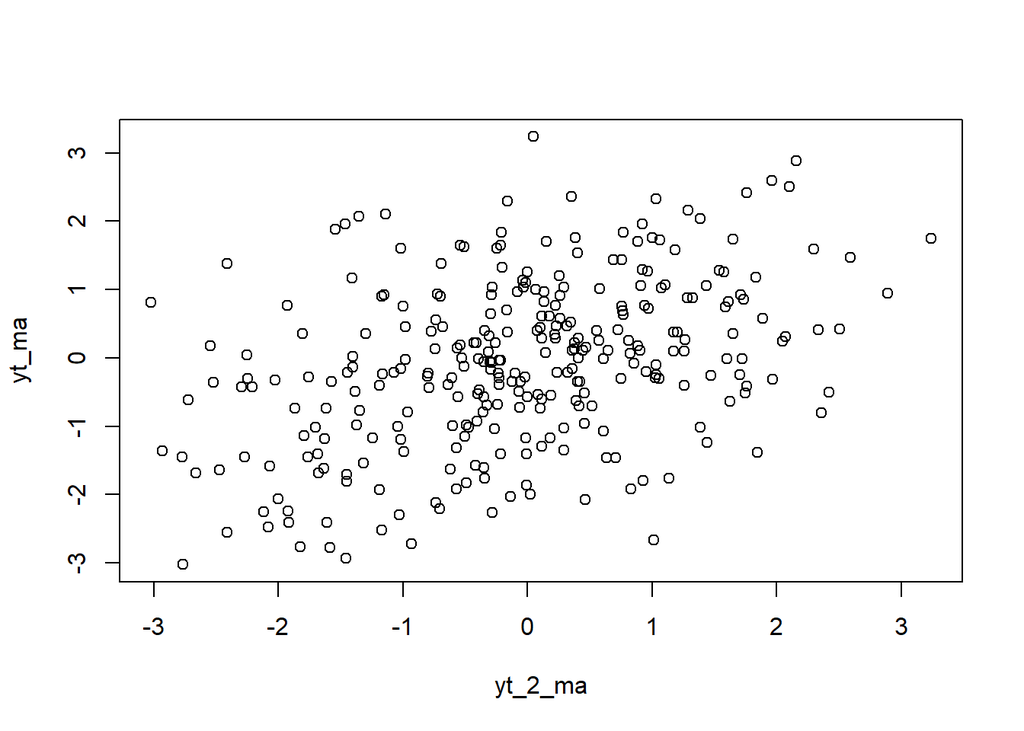

```r
plot(y=yt_ma,x=yt_2_ma)
```

Berdasarkan scatter plot terlihat ada hubungan antara $Y_t$ dengan $Y_{t-2}$

```r
cor(yt_ma,yt_2_ma)
```

```
## [1] 0.4059564
```

Secara teoritis dapat dihitung dengan rumus:

$$\dfrac{\theta_2}{1+\theta_1^2+\theta_2^2}$$

```r
teoritis = theta_2/(1+theta_1^2+theta_2^2)
teoritis
```

```
## [1] 0.3947368
```

Korelasi $Y_t$ dengan $Y_{t-2}$ hasil simulasi mendekati nilai teoritis

#### Korelasi antara $Y_t$ dengan $Y_{t-3}$

```r
#Yt
yt_ma <- ma2[-c(1,2,3)]
yt_ma
```

```
##   [1]  0.099831997  0.142549584 -0.739257662  0.077337001  0.134539330
##   [6]  0.400082192  0.825508193 -0.345241818  0.062928662  0.404074861
##  [11]  1.003530963  1.538194429  1.758879938  1.283663007 -0.413690314
##  [16]  0.885264094  0.227250656  0.179397653  0.471624330 -1.171403193
##  [21]  0.150524260  0.901596142  1.707061612  0.113055285  0.923355767
##  [26]  0.294113193  1.289397306  1.032843489  2.158232404  2.331124051
##  [31]  2.888084509  0.416760008  0.950954496 -0.700904907 -0.204069609
##  [36]  0.906290094  1.322461210  1.060580383  0.883127254  1.723056075
##  [41]  1.706358481 -0.007771454 -0.248910133 -1.405899388  1.602825567
##  [46]  1.172781239 -0.007255608  0.381834510 -1.864013855  1.756848266
##  [51] -0.734343906  2.417072978  0.552773390 -0.504652232  0.405640068
##  [56] -1.150381763 -0.002710011  0.922859187  1.256738831  1.964604190
##  [61]  0.103219006 -0.311291184  0.447260161  0.083832493  0.114479708
##  [66] -0.537951263 -1.298179021  0.189567965  0.361043390 -0.541663467
##  [71] -0.159173265  1.651055541  2.296689228  1.733496550  1.587451769
```

[output cut: 45 more lines]

```r
#Yt-3
yt_3_ma <- ma2[-c(298,299,300)]
yt_3_ma
```

```
##   [1] -0.556759407  1.173156360 -0.567420342  0.099831997  0.142549584
##   [6] -0.739257662  0.077337001  0.134539330  0.400082192  0.825508193
##  [11] -0.345241818  0.062928662  0.404074861  1.003530963  1.538194429
##  [16]  1.758879938  1.283663007 -0.413690314  0.885264094  0.227250656
##  [21]  0.179397653  0.471624330 -1.171403193  0.150524260  0.901596142
##  [26]  1.707061612  0.113055285  0.923355767  0.294113193  1.289397306
##  [31]  1.032843489  2.158232404  2.331124051  2.888084509  0.416760008
##  [36]  0.950954496 -0.700904907 -0.204069609  0.906290094  1.322461210
##  [41]  1.060580383  0.883127254  1.723056075  1.706358481 -0.007771454
##  [46] -0.248910133 -1.405899388  1.602825567  1.172781239 -0.007255608
##  [51]  0.381834510 -1.864013855  1.756848266 -0.734343906  2.417072978
##  [56]  0.552773390 -0.504652232  0.405640068 -1.150381763 -0.002710011
##  [61]  0.922859187  1.256738831  1.964604190  0.103219006 -0.311291184
##  [66]  0.447260161  0.083832493  0.114479708 -0.537951263 -1.298179021
##  [71]  0.189567965  0.361043390 -0.541663467 -0.159173265  1.651055541
```

[output cut: 45 more lines]

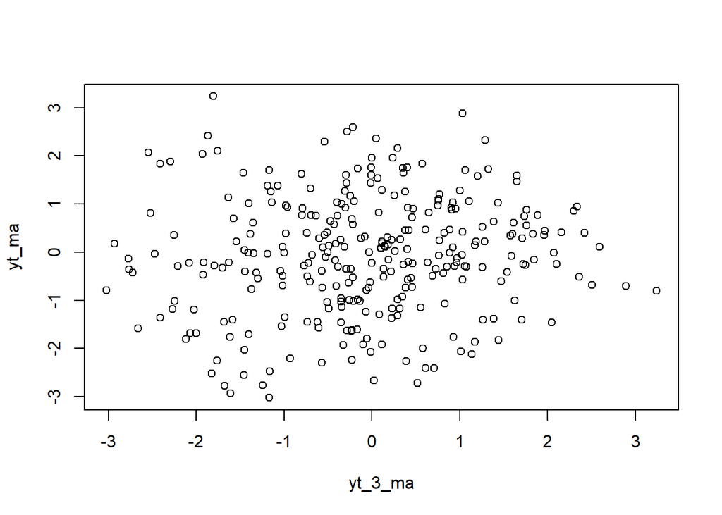

```r
plot(y = yt_ma, x = yt_3_ma)
```

Berdasarkan plot ACF, terlihat tidak ada hubungan antara $Y_t$ dengan $Y_{t-3}$

```r
cor(yt_ma, yt_3_ma)
```

```
## [1] 0.09417257
```

Secara teoritis $\rho_3$ = 0, korelasi hasil simulasi mendekati 0

# Auto Regressive

## Proses AR(2)

Akan dicoba membangkitkan proses AR dengan $\phi_1$ = 0.5 dan $\phi_2$ = 0.2 sebanyak 300 observasi dan c = 0.

### Manual

```r
set.seed(1062)
phi1 = 0.5
phi2 = 0.2

n<-length(wn)
ar2 <- c(1:n)

for (i in 3:n) {
  ar2[i]<-wn[i]+phi1*ar2[i-1]+phi2*ar2[i-2]
  }
ar2
```

```
##   [1]  1.0000000000  2.0000000000  0.4973727574  0.3256754567  0.9556425779
##   [6] -0.2798268475  0.0416672053  0.5968966546  0.4597813239  0.7343613106
##  [11] -0.1319411582  0.1492067860  0.7796148284  1.0896368055  1.5321007840
##  [16]  2.0083211041  1.6856907263  0.0661692526  1.5017569881  1.2457535123
##  [21]  0.2310488096  0.8241864745 -0.4815971338  0.1748162205  1.3563139085
##  [26]  1.7236252253  0.0227935332  1.1172873068  1.2190184714  1.4033382616
##  [31]  1.3566780218  2.6105340494  3.0003926078  3.3499551993  1.3064813080
##  [36]  1.8650248638  0.8573314062  0.4071160796  1.6410226256  1.9547291744
##  [41]  1.1854326542  1.2831672120  2.5540060668  2.3901575550  0.3502985468
##  [46]  0.4325905817 -0.2179594400  1.9144438606  1.6142377600 -0.2596343215
##  [51]  0.7343570599 -0.8955076728  1.6154735762 -0.1457954494  1.8272286498
##  [56]  1.2710743828 -0.6045359651  0.7678230283 -0.2504165639 -0.2585110141
##  [61]  1.1663198330  1.4220534867  1.7452613989  0.4055146630  0.0605467079
##  [66]  1.2060576490  0.5558558557  0.0005232723 -0.1835025950 -0.9606817915
##  [71]  0.1971018513  0.5032217398 -0.9178410556 -0.3919848303  2.0103017527
```

[output cut: 45 more lines]

### `arima.sim()`

```r
set.seed(1062)
ar22 <- arima.sim(list(order=c(2,0,0), ar=c(0.5,0.2)), n=300)
ar22
```

```
## Time Series:
## Start = 1
## End = 300
## Frequency = 1
##   [1]  1.7219531660  0.0215188429  1.1163155498  1.2182776549  1.4027735020
##   [6]  1.3562474787  2.6102058259  3.0001423875  3.3497644444  1.3063358864
##  [11]  1.8649140020  0.8572468911  0.4070516496  1.6409735076  1.9546917294
##  [16]  1.1854041081  1.2831454500  2.5539894766  2.3901449075  0.3502889050
##  [21]  0.4325832313 -0.2179650436  1.9144395888  1.6142345033 -0.2596368042
##  [26]  0.7343551672 -0.8955091157  1.6154724763 -0.1457962880  1.8272280105
##  [31]  1.2710738954 -0.6045363366  0.7678227451 -0.2504167798 -0.2585111787
##  [36]  1.1663197075  1.4220533911  1.7452613260  0.4055146074  0.0605466655
##  [41]  1.2060576167  0.5558558311  0.0005232535 -0.1835026093 -0.9606818024
##  [46]  0.1971018429  0.5032217334 -0.9178410604 -0.3919848340  2.0103017499
##  [51]  2.2877233751  1.3011133738  1.9768949160  1.9012281185  1.3141263870
```

[output cut: 49 more lines]

## Karakteristik AR(2)

### Plot Time Series

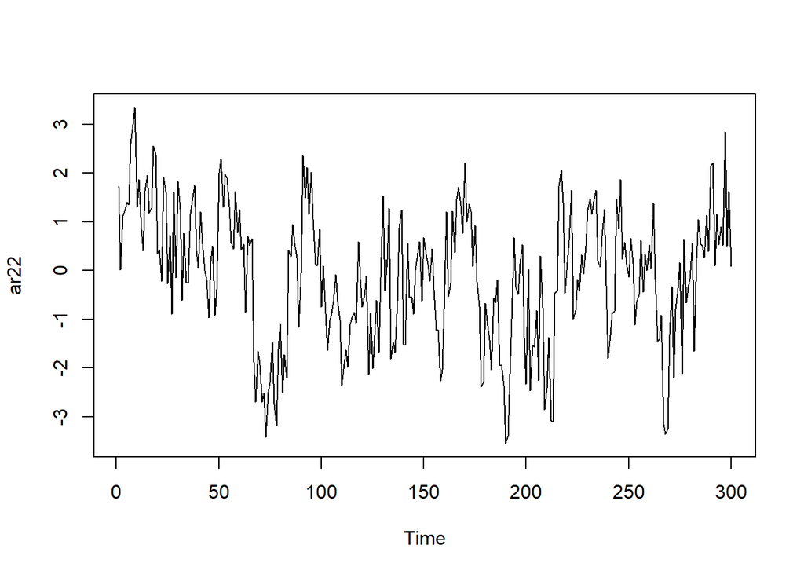

```r
ts.plot(ar22)
```

### Plot ACF

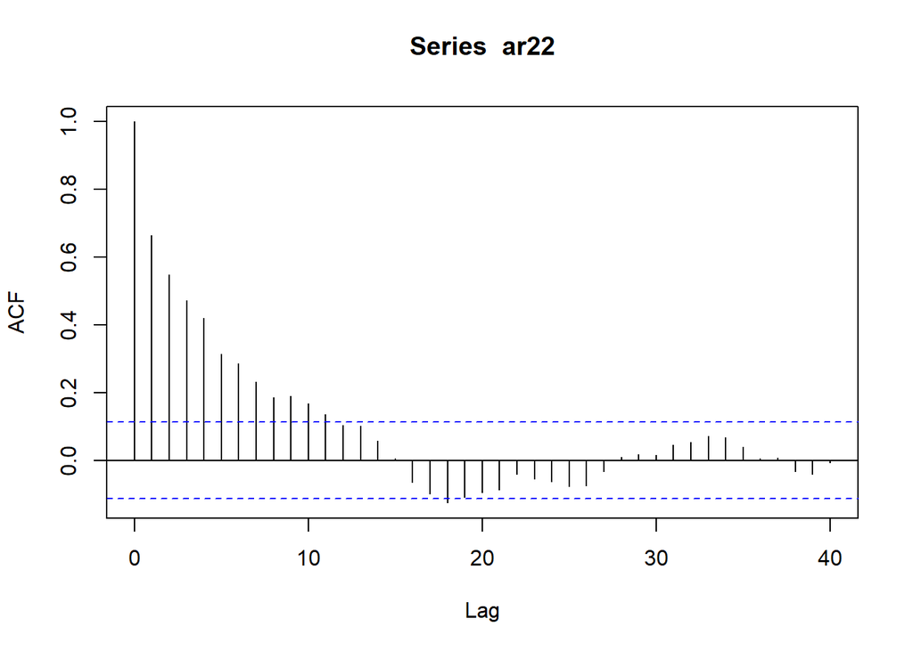

```r
acf(ar22,lag.max = 40)
```

Berdasarkan plot ACF tersebut terlihat bahwa plot ACF cenderung *tails off* dan cenderung membentuk pola grafik sinus

### Plot PACF

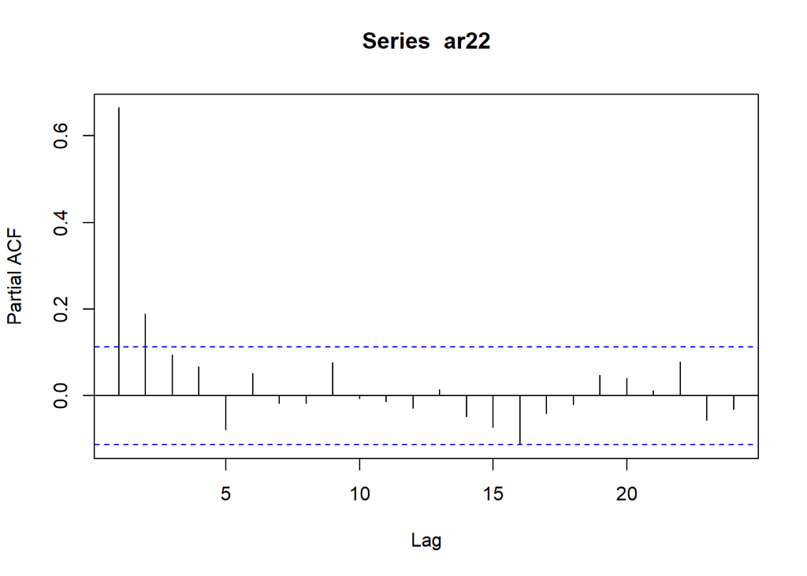

```r
pacf(ar22)
```

Berdasarkan plot PACF tersebut, terlihat bahwa plot PACF cuts off pada lag kedua

### Plot EACF

```r
TSA::eacf(ar22)
```

```
## AR/MA
##   0 1 2 3 4 5 6 7 8 9 10 11 12 13
## 0 x x x x x x x x x x x  o  o  o
## 1 x o o x x o o o o o o  o  o  o
## 2 x o o o o o o o o o o  o  o  o
## 3 x o x o o o o o o o o  o  o  o
## 4 x o o o o o o o o o o  o  o  o
## 5 x x o o o o o o o o o  o  o  o
## 6 x x o o o o o o o o o  o  o  o
## 7 x o o o x o o o o o o  o  o  o
```

### Scatter Plot antar Lag

#### Korelasi antara $Y_t$ dengan $Y_{t-1}$

```r
#Yt
yt_ar <- ar22[-1]
yt_ar
```

```
##   [1]  0.0215188429  1.1163155498  1.2182776549  1.4027735020  1.3562474787
##   [6]  2.6102058259  3.0001423875  3.3497644444  1.3063358864  1.8649140020
##  [11]  0.8572468911  0.4070516496  1.6409735076  1.9546917294  1.1854041081
##  [16]  1.2831454500  2.5539894766  2.3901449075  0.3502889050  0.4325832313
##  [21] -0.2179650436  1.9144395888  1.6142345033 -0.2596368042  0.7343551672
##  [26] -0.8955091157  1.6154724763 -0.1457962880  1.8272280105  1.2710738954
##  [31] -0.6045363366  0.7678227451 -0.2504167798 -0.2585111787  1.1663197075
##  [36]  1.4220533911  1.7452613260  0.4055146074  0.0605466655  1.2060576167
##  [41]  0.5558558311  0.0005232535 -0.1835026093 -0.9606818024  0.1971018429
##  [46]  0.5032217334 -0.9178410604 -0.3919848340  2.0103017499  2.2877233751
##  [51]  1.3011133738  1.9768949160  1.9012281185  1.3141263870  0.5758202299
##  [56]  0.4497137184  1.6210535883  0.7720910173  1.2589327923  0.4264380993
##  [61]  0.5411032118 -0.8606245321  0.6988672366  0.5238152732  0.6610349350
##  [66] -1.8772843017 -2.6997798854 -1.6470416271 -1.9387298697 -2.7009202512
##  [71] -2.5143494534 -3.4194509541 -2.4999540935 -2.2996715524 -1.4647729611
```

[output cut: 45 more lines]

```r
#Yt-1
yt_1_ar <- ar22[-300]
yt_1_ar
```

```
##   [1]  1.7219531660  0.0215188429  1.1163155498  1.2182776549  1.4027735020
##   [6]  1.3562474787  2.6102058259  3.0001423875  3.3497644444  1.3063358864
##  [11]  1.8649140020  0.8572468911  0.4070516496  1.6409735076  1.9546917294
##  [16]  1.1854041081  1.2831454500  2.5539894766  2.3901449075  0.3502889050
##  [21]  0.4325832313 -0.2179650436  1.9144395888  1.6142345033 -0.2596368042
##  [26]  0.7343551672 -0.8955091157  1.6154724763 -0.1457962880  1.8272280105
##  [31]  1.2710738954 -0.6045363366  0.7678227451 -0.2504167798 -0.2585111787
##  [36]  1.1663197075  1.4220533911  1.7452613260  0.4055146074  0.0605466655
##  [41]  1.2060576167  0.5558558311  0.0005232535 -0.1835026093 -0.9606818024
##  [46]  0.1971018429  0.5032217334 -0.9178410604 -0.3919848340  2.0103017499
##  [51]  2.2877233751  1.3011133738  1.9768949160  1.9012281185  1.3141263870
##  [56]  0.5758202299  0.4497137184  1.6210535883  0.7720910173  1.2589327923
##  [61]  0.4264380993  0.5411032118 -0.8606245321  0.6988672366  0.5238152732
##  [66]  0.6610349350 -1.8772843017 -2.6997798854 -1.6470416271 -1.9387298697
##  [71] -2.7009202512 -2.5143494534 -3.4194509541 -2.4999540935 -2.2996715524
```

[output cut: 45 more lines]

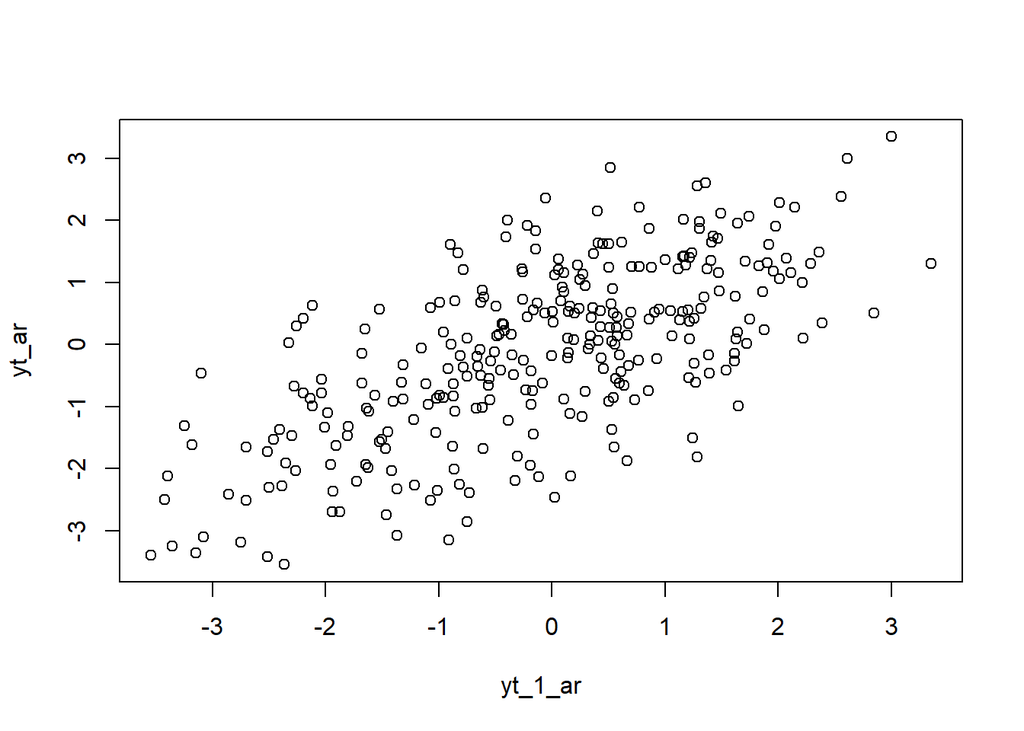

```r
plot(y=yt_ar,x=yt_1_ar)
```

Berdasarkan scatter plot, terlihat bahwa ada hubungan positif antara $Y_t$ dengan $Y_{t-1}$.

```r
cor(yt_ar,yt_1_ar)
```

```
## [1] 0.6666161
```

Secara teoritis dapat dihitung dengan rumus:

$$\rho_1 = \dfrac{\phi_1}{1-\phi_2}$$

```r
rho1_ar = phi1 / (1-phi2)
rho1_ar
```

```
## [1] 0.625
```

Korelasi antara $Y_t$ dengan $Y_{t-1}$ dari hasil simulasi mendekati dengan teoritis.

#### Korelasi antara $Y_t$ dengan $Y_{t-2}$

```r
#Yt
yt_ar <- ar22[-c(1,2)]
yt_ar
```

```
##   [1]  1.1163155498  1.2182776549  1.4027735020  1.3562474787  2.6102058259
##   [6]  3.0001423875  3.3497644444  1.3063358864  1.8649140020  0.8572468911
##  [11]  0.4070516496  1.6409735076  1.9546917294  1.1854041081  1.2831454500
##  [16]  2.5539894766  2.3901449075  0.3502889050  0.4325832313 -0.2179650436
##  [21]  1.9144395888  1.6142345033 -0.2596368042  0.7343551672 -0.8955091157
##  [26]  1.6154724763 -0.1457962880  1.8272280105  1.2710738954 -0.6045363366
##  [31]  0.7678227451 -0.2504167798 -0.2585111787  1.1663197075  1.4220533911
##  [36]  1.7452613260  0.4055146074  0.0605466655  1.2060576167  0.5558558311
##  [41]  0.0005232535 -0.1835026093 -0.9606818024  0.1971018429  0.5032217334
##  [46] -0.9178410604 -0.3919848340  2.0103017499  2.2877233751  1.3011133738
##  [51]  1.9768949160  1.9012281185  1.3141263870  0.5758202299  0.4497137184
##  [56]  1.6210535883  0.7720910173  1.2589327923  0.4264380993  0.5411032118
##  [61] -0.8606245321  0.6988672366  0.5238152732  0.6610349350 -1.8772843017
##  [66] -2.6997798854 -1.6470416271 -1.9387298697 -2.7009202512 -2.5143494534
##  [71] -3.4194509541 -2.4999540935 -2.2996715524 -1.4647729611 -2.7486035740
```

[output cut: 45 more lines]

```r
#Yt-1
yt_2_ar <- ar22[-c(299,300)]
yt_2_ar
```

```
##   [1]  1.7219531660  0.0215188429  1.1163155498  1.2182776549  1.4027735020
##   [6]  1.3562474787  2.6102058259  3.0001423875  3.3497644444  1.3063358864
##  [11]  1.8649140020  0.8572468911  0.4070516496  1.6409735076  1.9546917294
##  [16]  1.1854041081  1.2831454500  2.5539894766  2.3901449075  0.3502889050
##  [21]  0.4325832313 -0.2179650436  1.9144395888  1.6142345033 -0.2596368042
##  [26]  0.7343551672 -0.8955091157  1.6154724763 -0.1457962880  1.8272280105
##  [31]  1.2710738954 -0.6045363366  0.7678227451 -0.2504167798 -0.2585111787
##  [36]  1.1663197075  1.4220533911  1.7452613260  0.4055146074  0.0605466655
##  [41]  1.2060576167  0.5558558311  0.0005232535 -0.1835026093 -0.9606818024
##  [46]  0.1971018429  0.5032217334 -0.9178410604 -0.3919848340  2.0103017499
##  [51]  2.2877233751  1.3011133738  1.9768949160  1.9012281185  1.3141263870
##  [56]  0.5758202299  0.4497137184  1.6210535883  0.7720910173  1.2589327923
##  [61]  0.4264380993  0.5411032118 -0.8606245321  0.6988672366  0.5238152732
##  [66]  0.6610349350 -1.8772843017 -2.6997798854 -1.6470416271 -1.9387298697
##  [71] -2.7009202512 -2.5143494534 -3.4194509541 -2.4999540935 -2.2996715524
```

[output cut: 45 more lines]

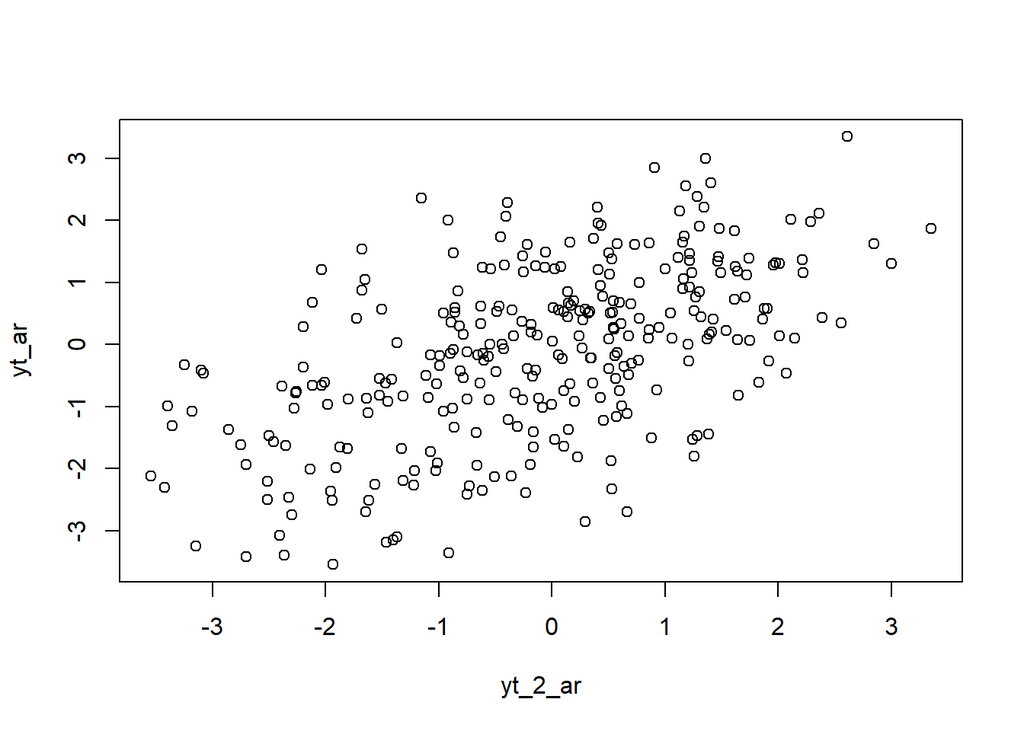

```r
plot(y=yt_ar,x=yt_2_ar)
```

Berdasarkan scatter plot, terdapat hubungan positif antara $Y_t$ dengan $Y_{t-2}$

```r
cor(yt_ar, yt_2_ar)
```

```
## [1] 0.5505346
```

Secara teoritis dapat dihitung dengan rumus:

$$\rho_2 = \phi_1\rho_1 + \phi_2\rho_0$$

dengan $\rho_0$ = 1

```r
rho2_ar = phi1*rho1_ar + phi2*1
rho2_ar
```

```
## [1] 0.5125
```

Korelasi antara $Y_t$ dengan $Y_{t-2}$ dari hasil simulasi mendekati dengan teoritis.